# A performance example

## A performance example

Before we measure performance of the main functionality of the package, note that something simple as '(a:b)[-i]' can and has been accelerated in this package:

```r
a <- 1L
b <- 1e7L
i <- sample(a:b,1e3)
x <- c(
  R = median(microbenchmark((a:b)[-i], times=times)$time)
, bit = median(microbenchmark(bit_rangediff(c(a,b), i), times=times)$time)
, merge = median(microbenchmark(merge_rangediff(c(a,b), bit_sort(i)), times=times)$time)
)
knitr::kable(as.data.frame(as.list(x/x["R"]*100)), caption="% of time relative to R", digits=1)
```

Table: % of time relative to R

| R | bit | merge |
| --- | --- | --- |
| 100 | 22.7 | 22.6 |

The vignette is compiled with the following performance settings: 5 replications with domain size small 1000 and big 10<sup>6</sup>, sample size small 1000 and big 10<sup>6</sup>.

## Boolean data types

> “A designer knows he has achieved perfection not when there is nothing left to add, but when there is nothing left to take away.”  
> “Il semble que la perfection soit atteinte non quand il n'y a plus rien à ajouter, mais quand il n'y a plus rien à retrancher”  
> (Antoine de St. Exupery, Terre des Hommes (Gallimard, 1939), p. 60.)

We compare memory consumption (n=1e+06) and runtime (median of 5 replications) of the different `booltype`s for the following filter scenarios:

Table: selection characteristic

| coin | often | rare | chunk |
| --- | --- | --- | --- |
| random 50% | random 99% | random 1% | contiguous chunk of 5% |

There are substantial savings in skewed filter situations:

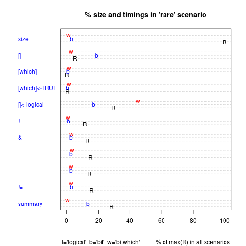

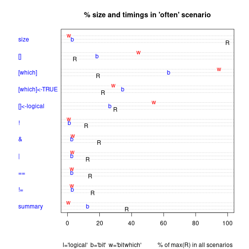

Even in non-skewed situations the new booltypes are competitive:

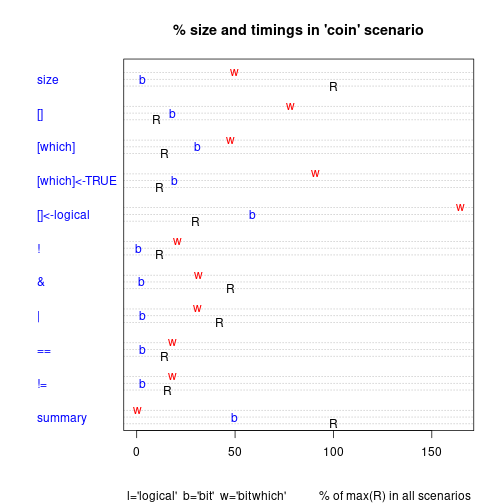

Detailed tables follow.

### % memory consumption of filter

Table: % bytes of logical

|  | coin | often | rare | chunk |
| --- | --- | --- | --- | --- |
| logical | 100.0 | 100.0 | 100.0 | 100.0 |
| bit | 3.2 | 3.2 | 3.2 | 3.2 |
| bitwhich | 49.9 | 1.0 | 1.0 | 5.0 |
| which | 50.1 | 99.0 | 1.0 | 5.0 |
| ri | NA | NA | NA | 0.0 |

### % time extracting

Table: % time of logical

|  | coin | often | rare | chunk |
| --- | --- | --- | --- | --- |
| logical | 9.9 | 4.6 | 5.2 | NA |
| bit | 18.2 | 18.4 | 18.7 | NA |
| bitwhich | 77.9 | 44.4 | 2.6 | NA |
| which | NA | NA | NA | NA |
| ri | NA | NA | NA | NA |

### % time assigning

Table: % time of logical

|  | coin | often | rare | chunk |
| --- | --- | --- | --- | --- |
| logical | 29.6 | 29.8 | 29.5 | NA |
| bit | 58.9 | 26.4 | 16.9 | NA |
| bitwhich | 164.7 | 54.1 | 45.0 | NA |
| which | NA | NA | NA | NA |
| ri | NA | NA | NA | NA |

### % time subscripting with 'which'

Table: % time of logical

|  | coin | often | rare | chunk |
| --- | --- | --- | --- | --- |
| logical | 14.1 | 19.0 | 0.4 | NA |
| bit | 31.0 | 63.1 | 0.8 | NA |
| bitwhich | 47.7 | 94.8 | 1.4 | NA |
| which | NA | NA | NA | NA |
| ri | NA | NA | NA | NA |

### % time assigning with 'which'

Table: % time of logical

|  | coin | often | rare | chunk |
| --- | --- | --- | --- | --- |
| logical | 11.8 | 22.2 | 0.4 | NA |
| bit | 19.4 | 34.4 | 0.7 | NA |
| bitwhich | 90.7 | 28.5 | 1.6 | NA |
| which | NA | NA | NA | NA |
| ri | NA | NA | NA | NA |

### % time Boolean NOT

Table: % time for Boolean NOT

|  | coin | often | rare | chunk |
| --- | --- | --- | --- | --- |
| logical | 11.5 | 11.6 | 11.6 | 11.8 |
| bit | 1.0 | 1.1 | 1.0 | 1.1 |
| bitwhich | 20.7 | 0.8 | 0.7 | 2.7 |
| which | NA | NA | NA | NA |
| ri | NA | NA | NA | NA |

### % time Boolean AND

Table: % time for Boolean &

|  | coin | often | rare | chunk |
| --- | --- | --- | --- | --- |
| logical | 47.8 | 19.8 | 13.2 | 12.5 |
| bit | 2.7 | 2.7 | 2.7 | 2.8 |
| bitwhich | 31.6 | 3.3 | 3.0 | 5.5 |
| which | NA | NA | NA | NA |
| ri | NA | NA | NA | NA |

### % time Boolean OR

Table: % time for Boolean |

|  | coin | often | rare | chunk |
| --- | --- | --- | --- | --- |
| logical | 42.2 | 12.7 | 15.1 | 14.4 |
| bit | 2.8 | 2.7 | 2.8 | 2.7 |
| bitwhich | 30.7 | 3.0 | 3.2 | 5.8 |
| which | NA | NA | NA | NA |
| ri | NA | NA | NA | NA |

### % time Boolean EQUALITY

Table: % time for Boolean ==

|  | coin | often | rare | chunk |
| --- | --- | --- | --- | --- |
| logical | 14.0 | 14.2 | 14.3 | 14.3 |
| bit | 2.7 | 2.7 | 2.7 | 2.7 |
| bitwhich | 18.2 | 2.8 | 2.7 | 4.0 |
| which | NA | NA | NA | NA |
| ri | NA | NA | NA | NA |

### % time Boolean XOR

Table: % time for Boolean !=

|  | coin | often | rare | chunk |
| --- | --- | --- | --- | --- |
| logical | 15.7 | 15.6 | 15.8 | 16.2 |
| bit | 3.0 | 2.9 | 2.9 | 2.9 |
| bitwhich | 18.3 | 2.8 | 2.7 | 4.1 |
| which | NA | NA | NA | NA |
| ri | NA | NA | NA | NA |

### % time Boolean SUMMARY

Table: % time for Boolean summary

|  | coin | often |
| --- | --- | --- |
| logical | 100.0 | 36.9 |
| bit | 49.8 | 12.5 |

## Fast methods for `integer` set operations

> “The space-efficient structure of bitmaps dramatically reduced the run time of sorting”  
> (Jon Bently, Programming Pearls, Cracking the oyster, p. 7)

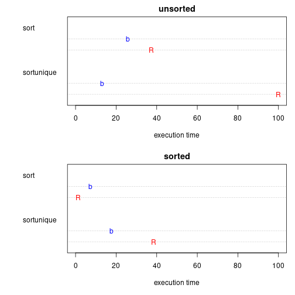

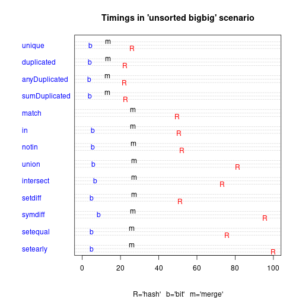

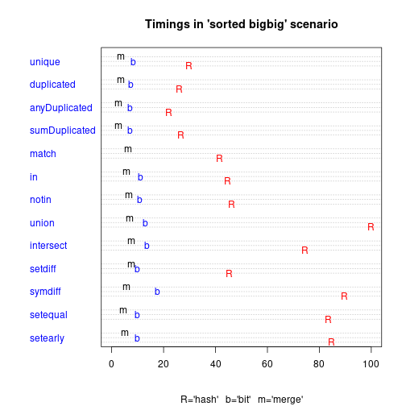

### % time for sorting

Table: sorted data relative to R's sort

|  | small | big |
| --- | --- | --- |
| sort | 224.6 | 613.8 |
| sortunique | 99.1 | 46.2 |

Table: unsorted data relative to R's sort

|  | small | big |
| --- | --- | --- |
| sort | 48.6 | 68.9 |
| sortunique | 21.1 | 13.0 |

### % time for unique

Table: sorted data relative to R

|  | small | big |
| --- | --- | --- |
| bit | 129.5 | 27.6 |
| merge | 28.2 | 11.5 |
| sort | 0.0 | 0.0 |

Table: unsorted data relative to R

|  | small | big |
| --- | --- | --- |
| bit | 135.6 | 16.5 |
| merge | 203.5 | 51.5 |
| sort | 174.0 | 45.0 |

### % time for duplicated

Table: sorted data relative to R

|  | small | big |
| --- | --- | --- |
| bit | 267.2 | 28.4 |
| merge | 42.5 | 13.6 |
| sort | 0.0 | 0.0 |

Table: unsorted data relative to R

|  | small | big |
| --- | --- | --- |
| bit | 261.2 | 17.3 |
| merge | 285.0 | 60.5 |
| sort | 243.0 | 52.6 |

### % time for anyDuplicated

Table: sorted data relative to R

|  | small | big |
| --- | --- | --- |
| bit | 174.3 | 32.4 |
| merge | 31.5 | 12.0 |
| sort | 0.0 | 0.0 |

Table: unsorted data relative to R

|  | small | big |
| --- | --- | --- |
| bit | 181.6 | 16.2 |
| merge | 276.6 | 59.6 |
| sort | 244.4 | 53.6 |

### % time for sumDuplicated

Table: sorted data relative to R

|  | small | big |
| --- | --- | --- |
| bit | 143.8 | 26.3 |
| merge | 26.3 | 9.6 |
| sort | 0.0 | 0.0 |

Table: unsorted data relative to R

|  | small | big |
| --- | --- | --- |
| bit | 132.2 | 17.2 |
| merge | 199.6 | 57.9 |
| sort | 176.0 | 52.2 |

### % time for match

Table: sorted data relative to R

|  | smallsmall | smallbig | bigsmall | bigbig |
| --- | --- | --- | --- | --- |
| bit | NA | NA | NA | NA |
| merge | 54.5 | 0 | 24.7 | 15.1 |
| sort | 0.0 | 0 | 0.0 | 0.0 |

Table: unsorted data relative to R

|  | smallsmall | smallbig | bigsmall | bigbig |
| --- | --- | --- | --- | --- |
| bit | NA | NA | NA | NA |
| merge | 437.2 | 53.9 | 119.0 | 53.7 |
| sort | 381.2 | 53.9 | 105.7 | 47.4 |

### % time for in

Table: sorted data relative to R

|  | smallsmall | smallbig | bigsmall | bigbig |
| --- | --- | --- | --- | --- |
| bit | 208.7 | 6.6 | 15.3 | 24.7 |
| merge | 42.6 | 0.0 | 21.7 | 13.0 |
| sort | 0.0 | 0.0 | 0.0 | 0.0 |

Table: unsorted data relative to R

|  | smallsmall | smallbig | bigsmall | bigbig |
| --- | --- | --- | --- | --- |
| bit | 224.1 | 3.3 | 8.5 | 10.7 |
| merge | 388.1 | 51.9 | 103.0 | 52.1 |
| sort | 343.8 | 51.9 | 90.7 | 46.4 |

### % time for notin

Table: sorted data relative to R

|  | smallsmall | smallbig | bigsmall | bigbig |
| --- | --- | --- | --- | --- |
| bit | 278.0 | 6.9 | 13.6 | 23.8 |
| merge | 44.8 | 0.0 | 18.1 | 14.5 |
| sort | 0.0 | 0.0 | 0.0 | 0.0 |

Table: unsorted data relative to R

|  | smallsmall | smallbig | bigsmall | bigbig |
| --- | --- | --- | --- | --- |
| bit | 303.5 | 3.4 | 8.0 | 10.5 |
| merge | 330.1 | 52.0 | 92.8 | 51.6 |
| sort | 286.0 | 52.0 | 82.0 | 45.2 |

### % time for union

Table: sorted data relative to R

|  | smallsmall | smallbig | bigsmall | bigbig |
| --- | --- | --- | --- | --- |
| bit | 84.8 | 23.2 | 26.4 | 13.1 |
| merge | 54.3 | 9.4 | 9.5 | 7.1 |
| sort | 0.0 | 0.0 | 0.0 | 0.0 |

Table: unsorted data relative to R

|  | smallsmall | smallbig | bigsmall | bigbig |
| --- | --- | --- | --- | --- |
| bit | 86.4 | 15.3 | 15.5 | 7.4 |
| merge | 207.9 | 47.2 | 47.5 | 33.3 |
| sort | 154.1 | 41.8 | 41.9 | 29.0 |

### % time for intersect

Table: sorted data relative to R

|  | smallsmall | smallbig | bigsmall | bigbig |
| --- | --- | --- | --- | --- |
| bit | 90.1 | 16 | 23.9 | 18.3 |
| merge | 31.4 | 0 | 0.1 | 10.0 |
| sort | 0.0 | 0 | 0.0 | 0.0 |

Table: unsorted data relative to R

|  | smallsmall | smallbig | bigsmall | bigbig |
| --- | --- | --- | --- | --- |
| bit | 86.2 | 8.6 | 13.8 | 9.1 |
| merge | 181.8 | 54.6 | 98.5 | 37.2 |
| sort | 152.6 | 54.5 | 98.5 | 32.1 |

### % time for setdiff

Table: sorted data relative to R

|  | smallsmall | smallbig | bigsmall | bigbig |
| --- | --- | --- | --- | --- |
| bit | 99.3 | 10.2 | 17.5 | 21.7 |
| merge | 43.4 | 0.0 | 6.5 | 16.5 |
| sort | 0.0 | 0.0 | 0.0 | 0.0 |

Table: unsorted data relative to R

|  | smallsmall | smallbig | bigsmall | bigbig |
| --- | --- | --- | --- | --- |
| bit | 102.4 | 5.2 | 12.2 | 9.4 |
| merge | 277.1 | 51.3 | 36.7 | 53.4 |
| sort | 232.0 | 51.3 | 32.5 | 46.0 |

### % time for symdiff

Table: sorted data relative to R

|  | smallsmall | smallbig | bigsmall | bigbig |
| --- | --- | --- | --- | --- |
| bit | 76.0 | 12.4 | 12.4 | 19.6 |
| merge | 15.9 | 3.4 | 3.3 | 6.4 |
| sort | 0.0 | 0.0 | 0.0 | 0.0 |

Table: unsorted data relative to R

|  | smallsmall | smallbig | bigsmall | bigbig |
| --- | --- | --- | --- | --- |
| bit | 76.6 | 7.5 | 7.4 | 9.0 |
| merge | 115.8 | 17.2 | 17.0 | 27.7 |
| sort | 100.0 | 15.1 | 15.0 | 24.6 |

### % time for setequal

Table: sorted data relative to R

|  | smallsmall | smallbig | bigsmall | bigbig |
| --- | --- | --- | --- | --- |
| bit | 105.5 | 107.4 | 11.3 | 11.8 |
| merge | 27.8 | 26.6 | 5.5 | 5.4 |
| sort | 0.0 | 0.0 | 0.0 | 0.0 |

Table: unsorted data relative to R

|  | smallsmall | smallbig | bigsmall | bigbig |
| --- | --- | --- | --- | --- |
| bit | 113.2 | 117.2 | 6.4 | 6.4 |
| merge | 200.8 | 75200.9 | 18.6 | 34.0 |
| sort | 173.3 | 75174.1 | 15.5 | 31.0 |

### % time for setearly

Table: sorted data relative to R

|  | smallsmall | smallbig | bigsmall | bigbig |
| --- | --- | --- | --- | --- |
| bit | 107.4 | 6.5 | 16.5 | 11.6 |
| merge | 28.4 | 0.0 | 0.1 | 5.9 |
| sort | 0.0 | 0.0 | 0.0 | 0.0 |

Table: unsorted data relative to R

|  | smallsmall | smallbig | bigsmall | bigbig |
| --- | --- | --- | --- | --- |
| bit | 117.1 | 3.3 | 8.7 | 5.0 |
| merge | 206.4 | 37.9 | 104.2 | 26.0 |
| sort | 177.8 | 37.9 | 104.1 | 23.5 |